# Projekt zaliczeniowy- analiza filmów (EDA)

Emilia Lehmann

2026-01-19

## Wprowadzenie

Przeprowadziłam Eksploracyjną Analizę Danych (EDA) obszernego zbioru informacji o filmach z bazy Kaggle. Głównym celem analizy jest zrozumienie mechanizmów rządzących rynkiem filmowym poprzez odpowiedź na szereg pytań badawczych. Orginalna baza danych została stworzona z myślą o tworzeniu systemów rekomendacji filmów. Składa się z blisko 5 000 wierszy danych (dokładniej 4 803 filmów). Każdy film jest opisanny za pomocą 24 kolumn.

## Zmienne, których będę używać to:

**budget** (num)- budżet filmu w dolarach.

**genres** (chr)- wszystkie gatunki, do których należy film.

**original_language** (chr)– kod języka (np. en -english, pl -polish), w którym film został nakręcony.

**original_title** (chr)– tytuł filmu w języku oryginalnym.

**popularity** (num)– wskaźnik liczbowy określający popularność filmu w serwisie.

**release_date** (Date)– data premiery kinowej.

**revenue** (num)– całkowity przychód ze sprzedaży biletów (box office) w dolarach.

**runtime** (num)– czas trwania filmu w minutach.

**title** (chr)– tytuł filmu (najczęściej w języku angielskim).

**vote_average** (num)– średnia ocen wystawionych przez użytkowników w skali od 1 do 10 w serwisie.

**vote_count** (num)– łączna liczba oddanych głosów w serwisie.

**director** (chr)- reżyser filmu.

## Sprawdzenie struktury danych.

```r
str(movies)
```

```
## spc_tbl_ [4,803 × 24] (S3: spec_tbl_df/tbl_df/tbl/data.frame)
##  $ index               : num [1:4803] 0 1 2 3 4 5 6 7 8 9 ...
##  $ budget              : num [1:4803] 2.37e+08 3.00e+08 2.45e+08 2.50e+08 2.60e+08 2.58e+08 2.60e+08 2.80e+08 2.50e+08 2.50e+08 ...
##  $ genres              : chr [1:4803] "Action Adventure Fantasy Science Fiction" "Adventure Fantasy Action" "Action Adventure Crime" "Action Crime Drama Thriller" ...
##  $ homepage            : chr [1:4803] "http://www.avatarmovie.com/" "http://disney.go.com/disneypictures/pirates/" "http://www.sonypictures.com/movies/spectre/" "http://www.thedarkknightrises.com/" ...
##  $ id                  : num [1:4803] 19995 285 206647 49026 49529 ...
##  $ keywords            : chr [1:4803] "culture clash future space war space colony society" "ocean drug abuse exotic island east india trading company love of one's life" "spy based on novel secret agent sequel mi6" "dc comics crime fighter terrorist secret identity burglar" ...
##  $ original_language   : chr [1:4803] "en" "en" "en" "en" ...
##  $ original_title      : chr [1:4803] "Avatar" "Pirates of the Caribbean: At World's End" "Spectre" "The Dark Knight Rises" ...
##  $ overview            : chr [1:4803] "In the 22nd century, a paraplegic Marine is dispatched to the moon Pandora on a unique mission, but becomes tor"| __truncated__ "Captain Barbossa, long believed to be dead, has come back to life and is headed to the edge of the Earth with W"| __truncated__ "…
##  $ popularity          : num [1:4803] 150.4 139.1 107.4 112.3 43.9 ...
##  $ production_companies: chr [1:4803] "[{\"name\": \"Ingenious Film Partners\", \"id\": 289}, {\"name\": \"Twentieth Century Fox Film Corporation\", \"| __truncated__ "[{\"name\": \"Walt Disney Pictures\", \"id\": 2}, {\"name\": \"Jerry Bruckheimer Films\", \"id\": 130}, {\"name"| __truncated__ "…
##  $ production_countries: chr [1:4803] "[{\"iso_3166_1\": \"US\", \"name\": \"United States of America\"}, {\"iso_3166_1\": \"GB\", \"name\": \"United Kingdom\"}]" "[{\"iso_3166_1\": \"US\", \"name\": \"United States of America\"}]" "[{\"iso_3166_1\": \"GB\", \"name\": \"United Kingdom\"}, {\"iso_…
##  $ release_date        : Date[1:4803], format: "2009-12-10" "2007-05-19" ...
##  $ revenue             : num [1:4803] 2.79e+09 9.61e+08 8.81e+08 1.08e+09 2.84e+08 ...
##  $ runtime             : num [1:4803] 162 169 148 165 132 139 100 141 153 151 ...
##  $ spoken_languages    : chr [1:4803] "[{\"iso_639_1\": \"en\", \"name\": \"English\"}, {\"iso_639_1\": \"es\", \"name\": \"Espa\\u00f1ol\"}]" "[{\"iso_639_1\": \"en\", \"name\": \"English\"}]" "[{\"iso_639_1\": \"fr\", \"name\": \"Fran\\u00e7ais\"}, {\"iso_639_1\": \"en\", \"name\": \"English\"}…
##  $ status              : chr [1:4803] "Released" "Released" "Released" "Released" ...
##  $ tagline             : chr [1:4803] "Enter the World of Pandora." "At the end of the world, the adventure begins." "A Plan No One Escapes" "The Legend Ends" ...
##  $ title               : chr [1:4803] "Avatar" "Pirates of the Caribbean: At World's End" "Spectre" "The Dark Knight Rises" ...
##  $ vote_average        : num [1:4803] 7.2 6.9 6.3 7.6 6.1 5.9 7.4 7.3 7.4 5.7 ...
##  $ vote_count          : num [1:4803] 11800 4500 4466 9106 2124 ...
##  $ cast                : chr [1:4803] "Sam Worthington Zoe Saldana Sigourney Weaver Stephen Lang Michelle Rodriguez" "Johnny Depp Orlando Bloom Keira Knightley Stellan Skarsg\\u00e5rd Chow Yun-fat" "Daniel Craig Christoph Waltz L\\u00e9a Seydoux Ralph Fiennes Monica Bellucci" "Christian Bale Mich…
##  $ crew                : chr [1:4803] "[{'name': 'Stephen E. Rivkin', 'gender': 0, 'department': 'Editing', 'job': 'Editor', 'credit_id': '52fe4800925"| __truncated__ "[{'name': 'Dariusz Wolski', 'gender': 2, 'department': 'Camera', 'job': 'Director of Photography', 'credit_id':"| __truncated__ "…
##  $ director            : chr [1:4803] "James Cameron" "Gore Verbinski" "Sam Mendes" "Christopher Nolan" ...
##  - attr(*, "spec")=
##   .. cols(
##   ..   index = col_double(),
##   ..   budget = col_double(),
##   ..   genres = col_character(),
##   ..   homepage = col_character(),
##   ..   id = col_double(),
##   ..   keywords = col_character(),
##   ..   original_language = col_character(),
##   ..   original_title = col_character(),
##   ..   overview = col_character(),
##   ..   popularity = col_double(),
##   ..   production_companies = col_character(),
##   ..   production_countries = col_character(),
##   ..   release_date = col_date(format = ""),
##   ..   revenue = col_double(),
##   ..   runtime = col_double(),
##   ..   spoken_languages = col_character(),
##   ..   status = col_character(),
##   ..   tagline = col_character(),
##   ..   title = col_character(),
##   ..   vote_average = col_double(),
##   ..   vote_count = col_double(),
##   ..   cast = col_character(),
##   ..   crew = col_character(),
##   ..   director = col_character()
##   .. )
##  - attr(*, "problems")=<externalptr>
```

Widzę, że niektóre zmienne nie będą mi potrzebne, więc się ich “pozbędę”.

```r
movies<- movies|>
  select(title, director, release_date, genres, runtime, budget, revenue,  original_language, original_title, popularity, vote_average, vote_count)
```

```r
summary(movies)
```

```
##     title             director          release_date           genres
##  Length:4803        Length:4803        Min.   :1916-09-04   Length:4803
##  Class :character   Class :character   1st Qu.:1999-07-14   Class :character
##  Mode  :character   Mode  :character   Median :2005-10-03   Mode  :character
##                                        Mean   :2002-12-27
##                                        3rd Qu.:2011-02-16
##                                        Max.   :2017-02-03
##                                        NA's   :1
##     runtime          budget             revenue          original_language
##  Min.   :  0.0   Min.   :        0   Min.   :0.000e+00   Length:4803
##  1st Qu.: 94.0   1st Qu.:   790000   1st Qu.:0.000e+00   Class :character
##  Median :103.0   Median : 15000000   Median :1.917e+07   Mode  :character
##  Mean   :106.9   Mean   : 29045040   Mean   :8.226e+07
##  3rd Qu.:118.0   3rd Qu.: 40000000   3rd Qu.:9.292e+07
##  Max.   :338.0   Max.   :380000000   Max.   :2.788e+09
##  NA's   :2
##  original_title       popularity       vote_average      vote_count
##  Length:4803        Min.   :  0.000   Min.   : 0.000   Min.   :    0.0
##  Class :character   1st Qu.:  4.668   1st Qu.: 5.600   1st Qu.:   54.0
##  Mode  :character   Median : 12.922   Median : 6.200   Median :  235.0
##                     Mean   : 21.492   Mean   : 6.092   Mean   :  690.2
##                     3rd Qu.: 28.314   3rd Qu.: 6.800   3rd Qu.:  737.0
##                     Max.   :875.581   Max.   :10.000   Max.   :13752.0
##
```

Wyświetlam część wartości, by lepiej się zapoznać z tą bazą:

```r
head(movies)
```

```
## # A tibble: 6 × 12
##   title    director release_date genres runtime budget revenue original_language
##   <chr>    <chr>    <date>       <chr>    <dbl>  <dbl>   <dbl> <chr>
## 1 Avatar   James C… 2009-12-10   Actio…     162 2.37e8  2.79e9 en
## 2 Pirates… Gore Ve… 2007-05-19   Adven…     169 3   e8  9.61e8 en
## 3 Spectre  Sam Men… 2015-10-26   Actio…     148 2.45e8  8.81e8 en
## 4 The Dar… Christo… 2012-07-16   Actio…     165 2.5 e8  1.08e9 en
## 5 John Ca… Andrew … 2012-03-07   Actio…     132 2.6 e8  2.84e8 en
## 6 Spider-… Sam Rai… 2007-05-01   Fanta…     139 2.58e8  8.91e8 en
## # ℹ 4 more variables: original_title <chr>, popularity <dbl>,
## #   vote_average <dbl>, vote_count <dbl>
```

```r
tail(movies)
```

```
## # A tibble: 6 × 12
##   title    director release_date genres runtime budget revenue original_language
##   <chr>    <chr>    <date>       <chr>    <dbl>  <dbl>   <dbl> <chr>
## 1 Cavite   Neill D… 2005-03-12   Forei…      80      0       0 en
## 2 El Mari… Robert … 1992-09-04   Actio…      81 220000 2040920 es
## 3 Newlywe… Edward … 2011-12-26   Comed…      85   9000       0 en
## 4 Signed,… Scott S… 2013-10-13   Comed…     120      0       0 en
## 5 Shangha… Daniel … 2012-05-03   <NA>        98      0       0 en
## 6 My Date… Brian H… 2005-08-05   Docum…      90      0       0 en
## # ℹ 4 more variables: original_title <chr>, popularity <dbl>,
## #   vote_average <dbl>, vote_count <dbl>
```

Wyświetlam tylko te “przydatniejsze” zmienne.

```r
analiza<-movies |>
  select(title, genres, revenue, budget, vote_average, vote_count)

analiza
```

```
## # A tibble: 4,803 × 6
##    title                           genres revenue budget vote_average vote_count
##    <chr>                           <chr>    <dbl>  <dbl>        <dbl>      <dbl>
##  1 Avatar                          Actio…  2.79e9 2.37e8          7.2      11800
##  2 Pirates of the Caribbean: At W… Adven…  9.61e8 3   e8          6.9       4500
##  3 Spectre                         Actio…  8.81e8 2.45e8          6.3       4466
##  4 The Dark Knight Rises           Actio…  1.08e9 2.5 e8          7.6       9106
##  5 John Carter                     Actio…  2.84e8 2.6 e8          6.1       2124
##  6 Spider-Man 3                    Fanta…  8.91e8 2.58e8          5.9       3576
##  7 Tangled                         Anima…  5.92e8 2.6 e8          7.4       3330
##  8 Avengers: Age of Ultron         Actio…  1.41e9 2.8 e8          7.3       6767
##  9 Harry Potter and the Half-Bloo… Adven…  9.34e8 2.5 e8          7.4       5293
## 10 Batman v Superman: Dawn of Jus… Actio…  8.73e8 2.5 e8          5.7       7004
## # ℹ 4,793 more rows
```

# Analiza bazy danych i postawienie pytań badawczych.

## Pytanie 1: Ile filmów danego gatunku znajduje się w tej bazie?

Zanim zacznę badać zarobki, oceny i bardziej szczegółowe dane, sprawdzę, który gatunek dominuje.

```r
pyt1 <- movies |>
 separate_rows(genres , sep = " ") |>
  mutate(genres = ifelse(genres == "Science", "Science-Fiction",ifelse(genres == "TV", "TV Movie", genres))) |>
  filter(!genres %in% c("Fiction", "Movie")) |>
  filter(!is.na(genres)) |>
  select(original_title, genres ) |>
  group_by(genres ) |>
  summarise(number_of_films = n()) |>
  arrange(desc(number_of_films))
```

Jeden film może należeć do paru gatunków, dlatego musiałam podzielić zmienną “genres” tak by każdy wiersz znajdował się w jedej kategorii (niestety gatunki “Science Fiction” oraz “TV Movie” zostały rozdzielone, więc musiałam je na nowo “złączyć” i usunąc powtórki).

```r
pyt1
```

```
## # A tibble: 20 × 2
##    genres          number_of_films
##    <chr>                     <int>
##  1 Drama                      2297
##  2 Comedy                     1722
##  3 Thriller                   1259
##  4 Action                     1153
##  5 Romance                     890
##  6 Adventure                   790
##  7 Crime                       696
##  8 Science-Fiction             530
##  9 Horror                      519
## 10 Family                      510
## 11 Fantasy                     418
## 12 Mystery                     347
## 13 Animation                   234
## 14 History                     197
## 15 Music                       183
## 16 War                         142
## 17 Documentary                 110
## 18 Western                      80
## 19 Foreign                      34
## 20 TV Movie                      8
```

Widać tutaj, gatunki filmów z największą ilością produkcji.  
Największą grupę stanowią Dramaty, ten gatunek ma dość elastyczną definicje oraz szeroki zakres dlatego dużo filmów należy do tej kategorii, podczas gdy rodzaje jak np. “Western”(który znajduje się bardzo nisko w tym zestawieniu) ma bardzo charakterystyczną tematykę, klimat i obejmują mniejszą liczbę filmów. Więc nic w tym dziwnego, że “Drama” znajduje się tak wysoko.

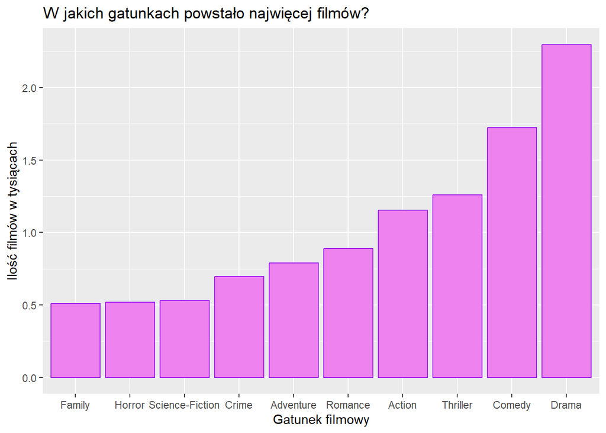

```r
pyt1_wykres <-pyt1|>
  top_n(10, number_of_films)

wykres1 <- ggplot(pyt1_wykres, aes(x = reorder(genres, number_of_films), y = number_of_films/1000)) +
  geom_col(color="purple", fill="violet") +
  labs(title = "W jakich gatunkach powstało najwięcej filmów?",x="Gatunek filmowy", y = "Ilość filmów w tysiącach")

wykres1
```

Wykres pokazuje jak wiele jest filmów w gatunku “Drama”, w porównaniu do 9 kolejnych kategorii z największą ilościa filmów (ponad 500 filmów więcej w porównaniu z “Comedy”).

## Pytanie 2: W których latach wyszło najwięcej filmów? Jak zmieniała się ilość wydawanych filmów na przestzreni lat?

Teraz sprawdzę kiedy powstało najwięcej filmów i czy widać, że coraz więcej filmów jest tworzonych.

```r
pyt2 <- movies |>
  separate(release_date, into = c("release_year", "release_month", "release_day"), sep = "-")|>
  filter(!is.na(release_year)) |>
  group_by(release_year )  |>
  summarise(number_of_films = n())
```

Rozdzielam date wydania filmu( release_date), na dzień wydania, miesiąc wydania, rok wydania po to by móc pogrupować filmy ze względu na rok wydania.

```r
pyt2_top<- pyt2 |>
  top_n(10, number_of_films)|>
  arrange(desc(number_of_films))

pyt2_top
```

```
## # A tibble: 10 × 2
##    release_year number_of_films
##    <chr>                  <int>
##  1 2009                     247
##  2 2014                     238
##  3 2006                     237
##  4 2013                     231
##  5 2008                     227
##  6 2010                     225
##  7 2011                     223
##  8 2005                     217
##  9 2015                     216
## 10 2012                     208
```

Najwiecej filmów jest wydawanych na przestrzeni lat 2005-2015. W roku 2009 ilośc filmów osiągneła maksymalną ilość.

```r
pyt2_wykres <- pyt2 |>
  mutate(release_year = as.numeric(release_year))
```

Zamieniam rok wydania filmu (release_year) na daną numeryczna by łatwiej utworzyć oś liczbową (z przedziałami a nie konkretnymi wartościami).

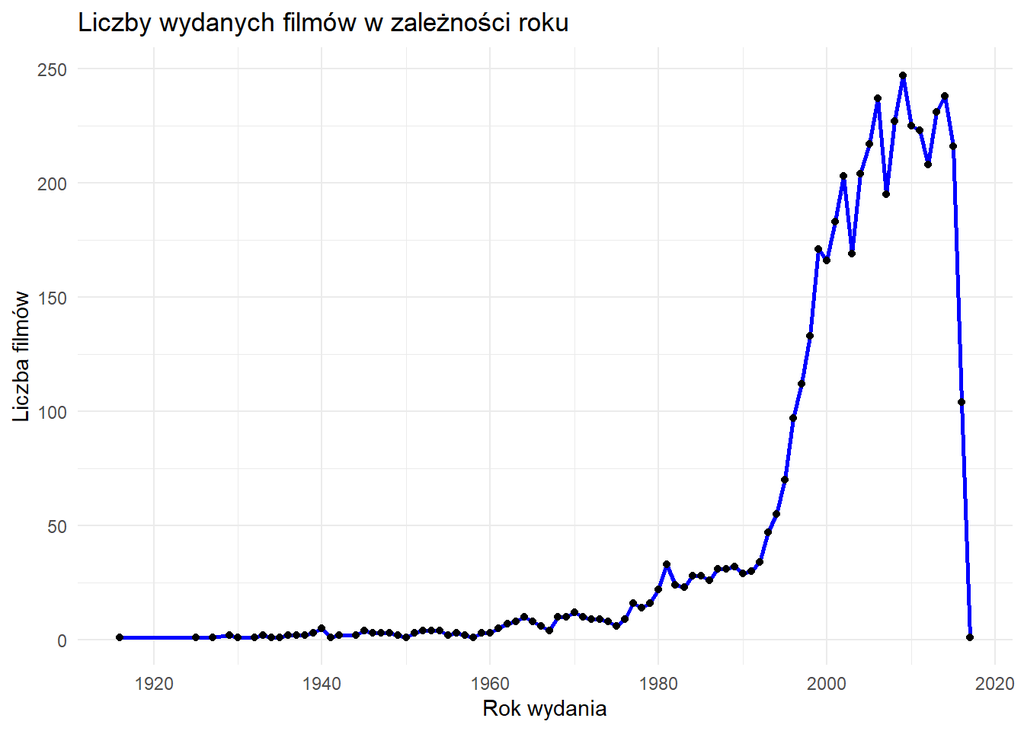

```r
wykres2 <- ggplot(pyt2_wykres, aes(x = release_year, y = number_of_films)) +
  geom_line(color = "blue", size = 1) +
  geom_point( linewidth = 1.5) +
  labs(
    title = "Liczby wydanych filmów w zależności roku",
    x = "Rok wydania",
    y = "Liczba filmów"
  ) +
  theme_minimal()
wykres2
```

Baza danych nie była dawno uaktualniana, widzimy, że w roku 2017 wydawno 1 film, co jest nieprawdą oraz brak danych po 2017. Dlatego pomimo wzrostu ilości filmów w poprzednich latach tu jest nagły spadek (nie obrazuje to faktycznych danych, tylko to że baza była tworzona do 2017 roku). Poza tym widzimy, że w XXI wieku tworzy się o wiele więcj filmów niż w XX wieku, jest związane z rozwojem technologi, ze zwiększającą się popularnością kina, itp.  
Przed 1990 rokiem ilość filmów nie przekaczała 50 filmów na rok, natomiast od 2000 (nie licząc lat 2016 i 2017 przez brak dnaych) ilość filmów nie spada ppniżej 150 filmów na rok.

## Pytanie 3: Ile zarobiło pięć najlepszych filmów (według średniej ocen)?

Przez, to że jest to rozbudowana baza danych, warunkiem żeby być jednym z najlepszych filmów, film musiał dostać co najmniej 6000 głosów, gdyż w tej znajdują się tu też filmy z oceną 10/10, ale dostały tylko 1 głos, więc byłoby to niesprawiedliwe by pokazać je jako najlepsze

Teraz przejdę do sprawdzania średnich ocen i zobaczę ile zarobiły filmy z najlepszymi ocenami. Czy ich świetna ocena będzie miała wpływ na ich zarobek?

```r
pyt3 <- movies |>
  filter(vote_count>6000)|>
  mutate(revenue=revenue/1000000)|>
  top_n(5, vote_average)|>
  arrange(desc(vote_average))|>
  select(original_title, vote_average, vote_count, revenue_in_mln=revenue)

pyt3
```

```
## # A tibble: 5 × 4
##   original_title           vote_average vote_count revenue_in_mln
##   <chr>                           <dbl>      <dbl>          <dbl>
## 1 The Shawshank Redemption          8.5       8205           28.3
## 2 Fight Club                        8.3       9413          101.
## 3 Pulp Fiction                      8.3       8428          214.
## 4 The Dark Knight                   8.2      12002         1005.
## 5 Forrest Gump                      8.2       7927          678.
```

Widzimy, że z tych pięciu filmów “The Dark Knight” zarobił najwięcej oraz najwięcej użytkowników na niego głosowało, jednak jeśli chodzi ośrednią ocen plasuje się dopiero na czwartym miejscu.

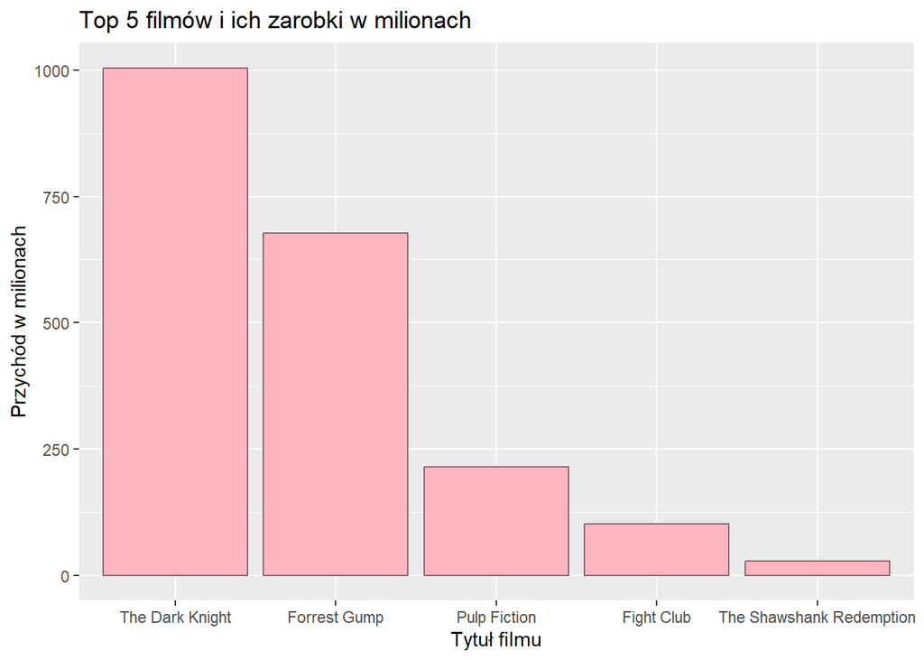

```r
wykres3 <-  ggplot(pyt3, aes(x = reorder(original_title, -revenue_in_mln), y = revenue_in_mln)) +
  geom_col(color="pink4", fill="lightpink") +
  labs(title = "Top 5 filmów i ich zarobki w milionach",x="Tytuł filmu", y = "Przychód w milionach")

wykres3
```

Jak widać na wykresie(i we wczesnijeszej tabeli), mimo bardzo dobrych opinii “The Shawshank Redemption” nie zarobił zbyt dużo pieniędzy ze sprzedaży biletów. Wysoka ocena użytkowników nie zawsze idzie w parze z przychodem kinowym. Najwidoczniej dużą popularność ten film zyskał lata po premierze.

## Jak rozkłada się gęstość ocen filmów w tej bazie danych?

Po tym jak poznałam wyniki “najlepszych filmów”, gdzie żaden z nich nie uzyskał oceny wyższej niż 9, sprawdzę jak rozkłada się gęstość ocen wśród tych wartości.

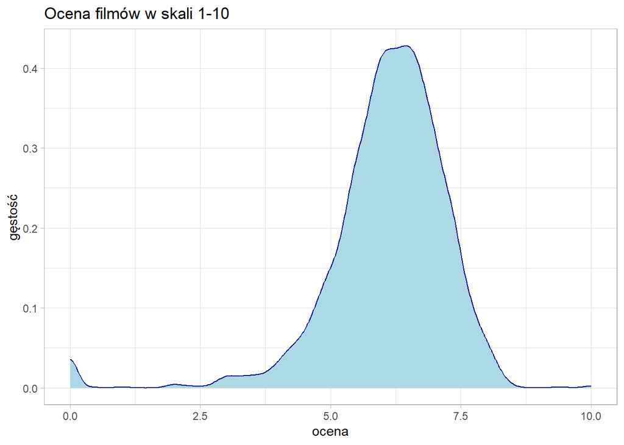

```r
wykres3a <- movies %>%
  ggplot() +
  geom_density(aes(x = vote_average),
               color = "darkblue", fill = "lightblue") +
  theme_light() +
  labs(title = "Ocena filmów w skali 1-10",
       x = "ocena",  y="gęstość")

wykres3a
```

Widzimy, że jest bardzo mało filmów fantastycznych (ocena od 9 do 10), spowodowne to jest najpewniej różnymi gustami, oczekiwaniami wobec filmu. Jest mała ilość filmów z oceną niską (0-1), może to być spowodowane słabą jakościa filmu (np. źle nakręcone sceny, zły scenariusz), gustem ludzi, albo małą popularnościa filmu (przez co mniej ludzi zaglosowało, że film jest dobry). Najwięcej jest filmów z ocenami średnimi (od 5 do 7,5), czyli filmy te najpewniej trafiły do óżnej publiczności, gdzie ludzie różnorodnie oceniali (np. któs dał 5, inna osoba 9, a nastepna 1) przez co średnia tego filmu znjaduje się “ww środku stawki”.

## Pytanie 4: Jakie jest Top 10 najlepiej zarabiających filmów? Ile zarobiły i jakie są ich oceny?

Skoro znamy już najlepsze filmy pod względem oceny, teraz znajdę 10 najlepiej zarabiających filmów i zobaczę ich oceny.

```r
pyt4 <- movies |>
  mutate(revenue=revenue/1000000)|>
  top_n(10, revenue )|>
  arrange(desc(revenue))|>
  select(title, revenue_in_mil = revenue, vote_average, vote_count)

pyt4
```

```
## # A tibble: 10 × 4
##    title                      revenue_in_mil vote_average vote_count
##    <chr>                               <dbl>        <dbl>      <dbl>
##  1 Avatar                              2788.          7.2      11800
##  2 Titanic                             1845.          7.5       7562
##  3 The Avengers                        1520.          7.4      11776
##  4 Jurassic World                      1514.          6.5       8662
##  5 Furious 7                           1506.          7.3       4176
##  6 Avengers: Age of Ultron             1405.          7.3       6767
##  7 Frozen                              1274.          7.3       5295
##  8 Iron Man 3                          1215.          6.8       8806
##  9 Minions                             1157.          6.4       4571
## 10 Captain America: Civil War          1153.          7.1       7241
```

Mimo dużych zarobków filmy nie mają bardzo dobrych ocen (wahają się od 6.4 do 7.5). Wielu ludzi mogło pójść do kina, ale nie być do końca usatysfakcjonowanymi seansem. Widzimy, że jest w tym rankingu aż 4 filmy wytwórni Marvel, tworzy ona filmy o superbohaterach, które mogą nie przemawiać do starszej publiczności (ludzie mogą myśleć, że bohaterowie, super moce, itd. są dziecinne), ale ma stałych odbiorców (nie tylko dzieci), którzy czekają na kolejne premiery filmów i sprawaiją, że filmy z uniwersum Marvel plasują się wysoko w rankingach zarobków.

## Pytanie 5: Które gatunki filmów są “najdroższe”?

Jakie są statystki opisowe zwiazane z budżetem konkretnych gatunków?

```r
pyt5 <- movies |>
  separate_rows(genres , sep = " ") |>
  mutate(genres = ifelse(genres == "Science", "Science-Fiction",ifelse(genres == "TV", "TV Movie", genres))) |>
  filter(!genres %in% c("Fiction", "Movie")) |>
  filter(!is.na(genres)) |>
  group_by(genres ) |>
  summarise(
    mean_budget = mean(budget),
    sd_budget= sd(budget),
    median_budget = median(budget),
    q1_budget = quantile(budget, 0.25),
    q3_budget= quantile(budget, 0.75),
    max_budget= max(budget),
  )|>
  arrange(desc(mean_budget))

pyt5
```

```
## # A tibble: 20 × 7
##    genres     mean_budget sd_budget median_budget q1_budget q3_budget max_budget
##    <chr>            <dbl>     <dbl>         <dbl>     <dbl>     <dbl>      <dbl>
##  1 Animation    66465902. 55870627.      60000000 19250000  100000000  260000000
##  2 Adventure    66326861. 62773139.      48000000 18000000  100000000  380000000
##  3 Fantasy      63551906. 63096431.      45500000 17225000   90000000  380000000
##  4 Science-F…   52028434. 58078144.      30000000  7000000   77500000  280000000
##  5 Action       51512061. 55230329.      35000000 10000000   70000000  380000000
##  6 Family       50488450. 53211145.      33000000  5625000   79500000  260000000
##  7 War          35075168. 36939918.      21500000  7435344.  57500000  175000000
##  8 Thriller     31805795. 37545194.      20000000  3500000   46500000  250000000
##  9 Mystery      30781215. 33642813.      20000000  3470000   45500000  190000000
## 10 History      29903467. 33588533.      20000000  4000000   40000000  155000000
## 11 Crime        27849808. 31677861.      19300000  4000000   42000000  250000000
## 12 Western      27668170. 44561071.      10000000  1150000   35750000  255000000
## 13 Comedy       25313421. 32734141.      14000000    39644   35000000  225000000
## 14 Drama        20678325. 28915911.      10000000       25   30000000  250000000
## 15 Romance      20183548. 25604891.      11250000    23250   30000000  200000000
## 16 Music        16005302. 20630561.       9000000        0   21500000  105000000
## 17 Horror       14574031. 21849342.       5952000    77500   20000000  200000000
## 18 Documenta…    2653288.  7496686.            51        0    1750000   60000000
## 19 TV Movie      1150000   1853953.             0        0    1750000    4200000
## 20 Foreign        658088.  1679632.             0        0          0    7000000
```

Wysoka średnia i mediana dla animacji wynika najprawdopodobniej z ogromnych nakładów na technologię CGI, rendering oraz inne nowoczesne technologię pozwalające współczesnym animacjom na realistyczne wyrażanie emocji, dbałość o detale, płynny ruch itp. Widać, że animacja ma stosunkowo wysoki kwartyl pierwszy, co oznacza, że w tym gatunku rzadko spotyka się filmy bardzo tanie, czyli próg wejścia jest wysoki. Średnia, a mediana bardzo często się różnią o wielkie kwoty (np. W “Fantasy” 64 miliony- śrdnia, a mediana jest o 18 milionó mniejsza). Oznacza to, że w tych gatunkach istnieje grupa bardzo drogich produkcji (co widać w kolumnie max_budget, tam filmy fantasy osiągają nawet do 380 milionów), które zawyżają średnią, podczas gdy połowa filmów w danej kategorii jest produkowana za znacznie mniejsze kwoty. W kolumnie odchylenie standardowe widzimy zazwyczaj duże wartości. Dla “Adventure” odchylenie to blisko 63 miliony, więc filmy w tej kategorii maja bardzo duże rozproszenie.

## A jak zarobki w porównaniu do budżetu? Oraz zysk z produkcji?

```r
pyt5a <- movies |>
  separate_rows(genres , sep = " ") |>
  mutate(genres = ifelse(genres == "Science", "Science-Fiction",ifelse(genres == "TV", "TV Movie", genres))) |>
  filter(!genres %in% c("Fiction", "Movie")) |>
  filter(!is.na(genres)) |>
  group_by(genres ) |>
  summarise(
   profit=mean(revenue)-mean(budget),
    relationship =mean(revenue)/mean(budget))|>
  arrange(desc(profit))

pyt5a
```

```
## # A tibble: 20 × 3
##    genres              profit relationship
##    <chr>                <dbl>        <dbl>
##  1 Animation       159227123.        3.40
##  2 Adventure       142333343.        3.15
##  3 Fantasy         130336545.        3.05
##  4 Family          111258799.        3.20
##  5 Science-Fiction 101365024.        2.95
##  6 Action           89731313.        2.74
##  7 War              49608917.        2.41
##  8 Thriller         49416907.        2.55
##  9 Mystery          47745364.        2.55
## 10 Comedy           45976078.        2.82
## 11 Romance          39265495.        2.95
## 12 Crime            38300854.        2.38
## 13 Music            32646119.        3.04
## 14 Drama            31437907.        2.52
## 15 Horror           28971046.        2.99
## 16 History          27620095.        1.92
## 17 Western          19517927.        1.71
## 18 Documentary       7185600.        3.71
## 19 Foreign           -293437.        0.554
## 20 TV Movie         -1150000         0
```

Mimo dużego budżetu animacje zarabiaja średnio najwięcej, są to więc zazwyczaj filmy, w które warto inwestować gdyz przynoszą zyski (w tej bazie danych przedstawione są tylko zarobki ze sprzedaży biletów, a filmy animowane też zarabiają najczęściej później na zabawkach, poprzez platformy streaming’owe, itp). Najmniejszy profit mają filmy “Tv movie”, gdzie róznica średnich z przychodu i kosztów jest ujemna. Stosunek przychodu do kosztów, jest wysoki u filmów z największym profitem, ale najwyższy ten wskaźnik ma “Documentary”, przez to, że wyprodukowanie takich filmów nie jest zbyt drogie, ale jest opłacalne.

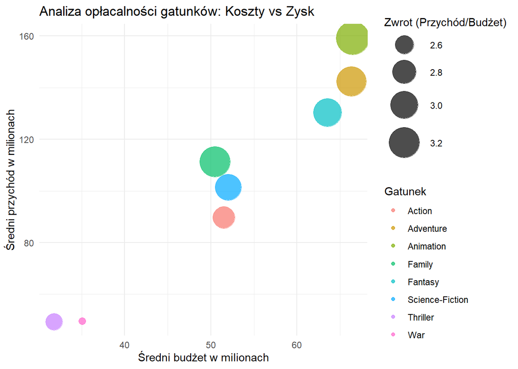

```r
pyt5a_wykres <- pyt5 |>
  select(genres, mean_budget) |>
  left_join(pyt5a, by = "genres")|>
  top_n(8, profit)

wykres5a<-ggplot(pyt5a_wykres, aes(x = mean_budget / 1000000, y = profit / 1000000, size = relationship, color = genres)) +
  geom_point(alpha = 0.7) +
  scale_size(range = c(3, 15)) +
  labs(
    title = "Analiza opłacalności gatunków: Koszty vs Zysk",
    x = "Średni budżet w milionach",
    y = "Średni przychód w milionach",
    size = "Zwrot (Przychód/Budżet)",
    color= "Gatunek"
  ) +
  theme_minimal()

wykres5a
```

Na wykresie przedstawiłam 8 najlepszych gatunków, jeżeli chodzi o profit. Gatunki “Animation”, “Fantasy” oraz “Adventure” znajdują się najwyżej, czyli wymagają najwyższych nakładów finansowych, ale generują jednak zdecydowanie najwyższe zyski. Animacje mają największy bąbelek na całym wykresie, co oznacza, że mimo wysokich kosztów, oferuje najlepszy stosunek przychodu do budżetu. Złoty środek osiągają gatunki: Family, Action, Science-Fiction. Przy średnim budżecie, maja średnie przychody, ale gatunek Family ma największy stosunek zarobków do nakładów (najwiekszy bąbelek). Thriller oraz War mają najniższe budżety generują też najniższe zyski.W przypadku gatunku wojennego zwrot jest bardzo mały (najmniejsza kropka), co sugeruje, że jest to gatunek najmniej opłacalny w tym zestawieniu.

## Pytanie 6: Jakie sa najlepsze filmy NIEanglojezyczne?

Najpierw sprawdźmy ogólne informacje dla filmów nieanglojęzycznych i anglojęzycznych:

```r
pyt6 <- movies |>
  mutate(language = ifelse(original_language == "en", "english", "other")) |>
  group_by(language) |>
  summarise(
    number_of_films = n(),
    mean_vote_average = mean(vote_average),
    mean_vote_count = median(vote_count),
    mean_revenue = mean(revenue))

pyt6
```

```
## # A tibble: 2 × 5
##   language number_of_films mean_vote_average mean_vote_count mean_revenue
##   <chr>              <int>             <dbl>           <dbl>        <dbl>
## 1 english             4505              6.07           251      86478850.
## 2 other                298              6.49            90.5    18492046.
```

## Jakie są najlepsze filmy pod względem zarobku?

```r
pyt6a <- movies|>
  filter(original_language!="en")|>
  mutate(revenue=revenue/1000000)|>
  top_n(5, revenue)|>
  arrange(desc(revenue))|>
  select(original_title, title, revenue_in_mln=revenue,original_language  )

pyt6a
```

```
## # A tibble: 5 × 4
##   original_title           title                revenue_in_mln original_language
##   <chr>                    <chr>                         <dbl> <chr>
## 1 千と千尋の神隠し         Spirited Away                  275. ja
## 2 ハウルの動く城           Howl's Moving Castle           235. ja
## 3 卧虎藏龙                 Crouching Tiger, Hi…           214. zh
## 4 西游记之孙悟空三打白骨精 The Monkey King 2              194. zh
## 5 崖の上のポニョ           Ponyo                          187. ja
```

Pierwsze miejsce, jeśli chodzi o największy przychód, zajmuje film animowany “Spirited Away”. W 5 najlepiej zarabiających filmach znajdują się trzy japońskie filmy (ja) oraz dwa chińskie (zh). Azjatyckie kino jest więc najlepsze pod tym względem.

## A jakie są najlepsze pod względem oceny?

```r
pyt6b <- movies|>
  filter(original_language!="en")|>
  mutate(revenue=revenue/1000000)|>
  top_n(5, vote_average)|>
  arrange(desc(vote_average))|>
  select(original_title, title, vote_average, original_language  )

pyt6b
```

```
## # A tibble: 7 × 4
##   original_title                  title           vote_average original_language
##   <chr>                           <chr>                  <dbl> <chr>
## 1 千と千尋の神隠し                Spirited Away            8.3 ja
## 2 ハウルの動く城                  Howl's Moving …          8.2 ja
## 3 もののけ姫                      Princess Monon…          8.2 ja
## 4 七人の侍                        Seven Samurai            8.2 ja
## 5 C'era una volta il West         Once Upon a Ti…          8.1 it
## 6 Cidade de Deus                  City of God              8.1 pt
## 7 Il buono, il brutto, il cattivo The Good, the …          8.1 it
```

W tej grupie również wygrywa “Spirited Away”. Znajduja się tu cztery filmy japońskie (ja), wszytskie na czterech pierwszych miejscach oraz dwa filmy włoskie (it) i jeden portugalski (pt). Drugie, trzecie i czwarte miejsce mają taką samośrednią głosów, również piąte, szóste i siódme miejsce są sobie równe. Tutaj dominacja filmów azjatyckich nie jest aż tak widoczna, gdyż mamy trzy filmy europejskie.

## Pytanie 7:Jacy reżyserzy stworzyli najwięcej filmów?

```r
pyt7 <- movies |>
  filter(!is.na(director)) |>
  group_by(director ) |>
  summarise(liczba = n()) |>
   top_n(4,liczba)|>
  arrange(desc(liczba))

pyt7
```

```
## # A tibble: 4 × 2
##   director         liczba
##   <chr>             <int>
## 1 Steven Spielberg     27
## 2 Woody Allen          21
## 3 Clint Eastwood       20
## 4 Martin Scorsese      20
```

Widzimy czterech mężczyzn, których dorobek filmowy to co najmniej 20. Najaktywniejszy z nich jest Steven Spilberg, który stworzył takie hity kinowe jak: “Szczęki”, “E.T”, “Park Jurajski”, “Lista Schindlera”.

## A jaki jest rozkład przychodów najaktywniejszych twórców?

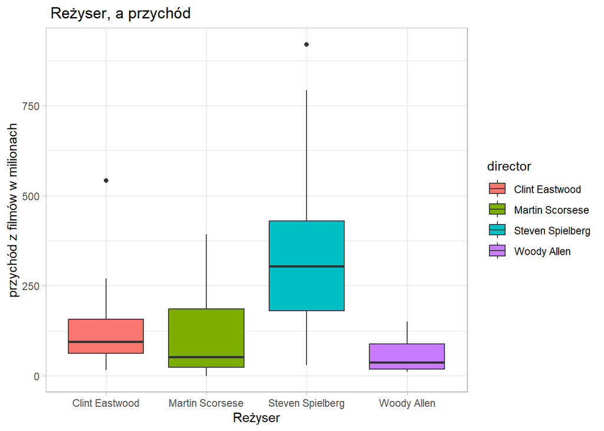

```r
pyt7_wykres <- movies |>
  filter(director %in% pyt7$director, revenue > 0)

wykres7 <- pyt7_wykres |>
  ggplot() +
  geom_boxplot(aes(x = director, y = revenue / 1000000, fill = director))+
  theme_light() +
  labs(title = " Reżyser, a przychód",
       x = "Reżyser",
       y = "przychód z filmów w milionach")

wykres7
```

## Pytanie 8: Jakie są statystyki filmów w danych dekadach?

```r
pyt8 <- movies |>
  separate(release_date, into = c("release_year", "release_month", "release_day"), sep = "-")|>
  mutate(release_year = as.numeric(release_year)) |>
  filter(!is.na(release_year) & release_year >= 1970) |>
  mutate(decade = ifelse(release_year >= 2010, "2010s",
                         ifelse(release_year >= 2000, "2000s",
                                ifelse(release_year >= 1990, "1990s",
                                       ifelse(release_year >= 1980, "1980s",
                                              ifelse(release_year >= 1970, "1970s", "Older"))))))|>
  group_by(decade)

pyt8_vote<- pyt8|>
  summarise(
    number_of_films = n(),
    mean_budget = mean(budget),
    median_revenu = median(revenue),
    mean_vote_average =mean(vote_average),
    sd_vote_average = sd(vote_average)  ) |>
  arrange(desc(decade))

pyt8_vote
```

```
## # A tibble: 5 × 6
##   decade number_of_films mean_budget median_revenu mean_vote_average
##   <chr>            <int>       <dbl>         <dbl>             <dbl>
## 1 2010s             1446   34461618.     21545954               5.86
## 2 2000s             2048   30473182.     19227664.              6.07
## 3 1990s              778   28669605.     18394303               6.24
## 4 1980s              278   12978157.     22049388.              6.37
## 5 1970s              109    7008181.     20000000               6.77
## # ℹ 1 more variable: sd_vote_average <dbl>
```

Wyraźnie widać stały wzrost ilości filmów tworzonych w danych dekadach. Co prawda w latach po 2010 jest mniej filmów niż w latach 2000-2009, ale to dlatego, że baza dancyh nie jest skończona- znajdują się tu tylko filmy wydane do 2016 roku- jestem więc pewna, że analiza przeprowadzona obecnie pokazałaby, że: liczba filmów wydanych od 2010 > liczba filmów wydanych w latach 2000-2009. średnie budżety filmów są coraz większe (spowodowane jest to przez: nowoczesne maszyny, produkcje “na większą skale”, itp., ale również inflacje), jednak średnie zarobki z filmów nie różnią się aż tak. Odchylenie standardowe ocen jest najniższe w latach 70. i rośnie w nowszych dekadach.Widzowie więc są coraz bardziej podzieleni w opiniach oraz obecnie mamy większy przekrój jakości, w starszych dekadach poziom jest “równie wysoki”.

```r
pyt8a<- pyt8|>
  summarise(
    mean_runtime = mean(runtime, na.rm = TRUE),
    median_runtime = median(runtime, na.rm = TRUE),
    sd_runtime = sd(runtime, na.rm = TRUE),
    max_runtime = max(runtime, na.rm = TRUE)) |>
  arrange(desc(decade))

pyt8a
```

```
## # A tibble: 5 × 5
##   decade mean_runtime median_runtime sd_runtime max_runtime
##   <chr>         <dbl>          <dbl>      <dbl>       <dbl>
## 1 2010s          104.            102       22.9         338
## 2 2000s          105.            102       20.2         276
## 3 1990s          110.            106       22.5         254
## 4 1980s          111.            106       22.5         229
## 5 1970s          116.            113       26.9         225
```

Filmy z dekady na dekadę stają się coraz krótsze. Przeciętna produkcja skróciła się o około 12-14 minut w ciągu pół wieku. Może to wynikać z paru rzeczy: 1. Zdolność ludzi do długotrwałego skupienia uwagi spada (tak zwany “Short Attention Span”). Reżyser zmoże więc się starać, aby tempo filmu było szybsze, a akcja bardziej skondensowana, by widz nie zaczął sięgać po telefon w trakcie seansu. 2. W filmach fantasy, itp. sceny z efektami specjalnymi kosztują setki tysięcy dolarów. Skrócenie filmu może przyniosić studiu ogromne oszczędności, nie wpływając drastycznie na fabułę. 3.Przez popularyzację seriali, filmy kinowe skupiają się teraz na bardziej skondensowanych wątkach. Rozbudowana fabuła lub sagi przeniosły się do formatów odcinkowych. W każdej dekadzie średnia jest nieco wyższa niż mediana, gdyż W każdej dekadzie trafiają się pojedyncze, ekstremalnie długie produkcje, które podwyższają średnią, podczas gdy większość filmów trzyma się bliżej 100-110 minut. Mimo skrócenia długości filmów, najdłuższy film został stworzony w latach 2010, a ten film to:

```r
pyt8b<-movies|>
  filter(runtime==338)

pyt8b
```

```
## # A tibble: 1 × 12
##   title  director   release_date genres runtime budget revenue original_language
##   <chr>  <chr>      <date>       <chr>    <dbl>  <dbl>   <dbl> <chr>
## 1 Carlos Olivier A… 2010-05-19   Crime…     338 1.80e7  871279 en
## # ℹ 4 more variables: original_title <chr>, popularity <dbl>,
## #   vote_average <dbl>, vote_count <dbl>
```

##Pytanie 9: Czy budżet wpływa na ocenę filmu?

```r
pyt9 <- movies |>
  filter(budget > 0, vote_count > 100)
```

Filtruje filmy z mniejszą ilościa głosów niż 100, by średnia ocena była sprawidliwa oraz produkcje, które w tej bazie danych mają przypisany budżet “0”.

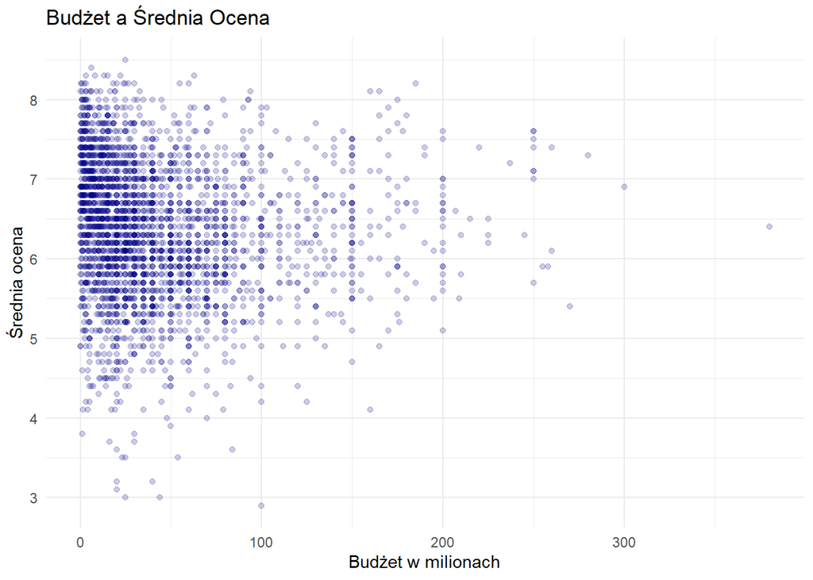

```r
wykres9<- pyt9|>
  ggplot(aes(x = budget / 1000000, y = vote_average)) +
  geom_point(alpha = 0.2, color = "blue4") +
  labs(title = "Budżet a Średnia Ocena",
       x = "Budżet w milionach", y = "Średnia ocena") +
  theme_minimal()

wykres9
```

Na podstawie wykresu możemy stwierdzić, że nie ma bezposredniego związku między budżetem filmu, a jego oceną. Punkty nie układają się w wyraźny skos (np. od lewego dolnego do prawego górnego rogu). Oznacza to, że współczynnik korelacji Persona jest bliski zeru. Zwiększenie budżetu nie gwarantuje wyższej oceny u widza. Produkcje z budżetem powyżej 200 milionów nie spadają poniżej oceny 5, ale też nie przebijają progu 8. Filmy te znajdują sie w stabilnej sytuacji.

## Jakie są zależności między budżetem, przychodem, średnią ocen i popularnością?

```r
pyt9a = cor(movies[,c("revenue", "budget", "vote_average", "popularity" )],
 method = "spearman")

round(pyt9a, 2)
```

```
##              revenue budget vote_average popularity
## revenue         1.00   0.76         0.24       0.78
## budget          0.76   1.00         0.07       0.65
## vote_average    0.24   0.07         1.00       0.36
## popularity      0.78   0.65         0.36       1.00
```

Korelacja przychodu i popularności jest najsilniejsza. Jest to dodatni związek (wraz ze wzrostem popularności, rośnie przychód filmu). Trochę mniej wysoka, ale dalej silna relacja występuje dla przychodu i budżetu. Wysokie nakłady finansowe statystycznie przekładają się na wysokie przychody. Brak korelacji występuje dla budżetu i średniej oceny, oznacza to, że kwota wydana na produkcję filmu nie ma praktycznie żadnego wpływu na to, czy film zostanie dobrze oceniony przez widzów.